# FinalAssignment_Solns

```python
import pandas as pd
import matplotlib.pyplot as plt
import seaborn as sns
from scipy import stats
```

The Facebook dataset is a generated dataset which consists of users that are not real but whose attributes are built using trends in real facebook users data. We will use this data to identify key users and provide correct recommendations to them.

```python
facebook = pd.read_csv("Data/pseudo_facebook.csv")
facebook.tail()
```

|  | userid | age | dob_day | dob_year | dob_month | gender | tenure | friend_count | friendships_initiated | likes | likes_received | mobile_likes | mobile_likes_received | www_likes | www_likes_received |
| --- | --- | --- | --- | --- | --- | --- | --- | --- | --- | --- | --- | --- | --- | --- | --- |
| 98998 | 1268299 | 68 | 4 | 1945 | 4 | female | 541.0 | 2118 | 341 | 3996 | 18089 | 3505 | 11887 | 491 | 6202 |
| 98999 | 1256153 | 18 | 12 | 1995 | 3 | female | 21.0 | 1968 | 1720 | 4401 | 13412 | 4399 | 10592 | 2 | 2820 |
| 99000 | 1195943 | 15 | 10 | 1998 | 5 | female | 111.0 | 2002 | 1524 | 11959 | 12554 | 11959 | 11462 | 0 | 1092 |
| 99001 | 1468023 | 23 | 11 | 1990 | 4 | female | 416.0 | 2560 | 185 | 4506 | 6516 | 4506 | 5760 | 0 | 756 |
| 99002 | 1397896 | 39 | 15 | 1974 | 5 | female | 397.0 | 2049 | 768 | 9410 | 12443 | 9410 | 9530 | 0 | 2913 |

Run the following code and answer the questions in the markdown cell below

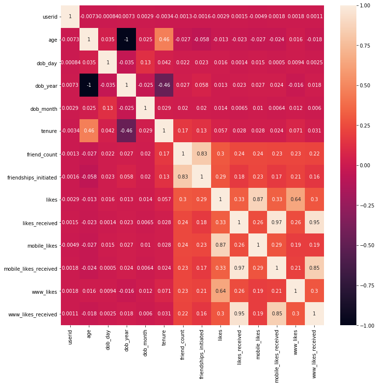

```python
plt.subplots(figsize=(12,12))
sns.heatmap(facebook.corr(), annot=True)
plt.show()
```

Why is there a diagonal of 1's running through the grid above? the diagonal of ones represent the correlation between variables, where it is one that means the variable is correlated to itself meaning a perfect correlation

Apart from the diagonal, which 3 pairs of variables have the strongest correlation?  
A strong corrleation means the values are close to 1. the 3 pairs of variables that have the strongest corelation are:

- Mobile_likes_recieved and likes_recieved -> Correlation=0.97
- www_likes_recieved and likes_recieved -> Correlation = 0.95
- mobile_likes and likes -> correlation = 0.87

Do you have a hypothesis for why each has a stong correlation?

- The hypothesis would be that these are similar variables and dont represent a real relationship for example mobile likes recieved is very similar to likes received, do we know if mobile likes and likes recieved are the same?

Use seaborn's *pairplot* or *PairGrid* functions to look for any relationships in the data.

```python
facebook.describe()
```

|  | userid | age | dob_day | dob_year | dob_month | tenure | friend_count | friendships_initiated | likes | likes_received | mobile_likes | mobile_likes_received | www_likes | www_likes_received |
| --- | --- | --- | --- | --- | --- | --- | --- | --- | --- | --- | --- | --- | --- | --- |
| count | 9.900300e+04 | 99003.000000 | 99003.000000 | 99003.000000 | 99003.000000 | 99001.000000 | 99003.000000 | 99003.000000 | 99003.000000 | 99003.000000 | 99003.000000 | 99003.000000 | 99003.000000 | 99003.000000 |
| mean | 1.597045e+06 | 37.280224 | 14.530408 | 1975.719776 | 6.283365 | 537.887375 | 196.350787 | 107.452471 | 156.078785 | 142.689363 | 106.116300 | 84.120491 | 49.962425 | 58.568831 |
| std | 3.440592e+05 | 22.589748 | 9.015606 | 22.589748 | 3.529672 | 457.649874 | 387.304229 | 188.786951 | 572.280681 | 1387.919613 | 445.252985 | 839.889444 | 285.560152 | 601.416348 |
| min | 1.000008e+06 | 13.000000 | 1.000000 | 1900.000000 | 1.000000 | 0.000000 | 0.000000 | 0.000000 | 0.000000 | 0.000000 | 0.000000 | 0.000000 | 0.000000 | 0.000000 |
| 25% | 1.298806e+06 | 20.000000 | 7.000000 | 1963.000000 | 3.000000 | 226.000000 | 31.000000 | 17.000000 | 1.000000 | 1.000000 | 0.000000 | 0.000000 | 0.000000 | 0.000000 |
| 50% | 1.596148e+06 | 28.000000 | 14.000000 | 1985.000000 | 6.000000 | 412.000000 | 82.000000 | 46.000000 | 11.000000 | 8.000000 | 4.000000 | 4.000000 | 0.000000 | 2.000000 |
| 75% | 1.895744e+06 | 50.000000 | 22.000000 | 1993.000000 | 9.000000 | 675.000000 | 206.000000 | 117.000000 | 81.000000 | 59.000000 | 46.000000 | 33.000000 | 7.000000 | 20.000000 |
| max | 2.193542e+06 | 113.000000 | 31.000000 | 2000.000000 | 12.000000 | 3139.000000 | 4923.000000 | 4144.000000 | 25111.000000 | 261197.000000 | 25111.000000 | 138561.000000 | 14865.000000 | 129953.000000 |

Are there any relationships that were not apparant from the correlation heatmap above?

#### The relationship of gender to likes isnt shown in the heatmap because a heatmap can only show numeric information.

```python
facebook_sample=facebook.sample(n=1000)
```

This function can take a long time to run, check the **metadata** and remove columns that you think are superfluous